# Aprendiendo `dplyr` paso a paso

De R base a tidyverse, con datos reales de vinos y salud

Autor/a

Roberto Álvarez elaborado con datos de UCI ML Repository y dataset_categorical_NA.csv

Fecha de publicación

25 de febrero de 2026

# ¿Por qué aprender `dplyr`?

Si ya conoces R base, sabes que se puede hacer casi cualquier cosa con él. Pero conforme los análisis crecen, el código puede volverse difícil de leer y mantener.

`dplyr` es un paquete del ecosistema **tidyverse** que te da una forma consistente y legible de manipular tablas de datos. No reemplaza a R base, sino que lo complementa: es R base con mejores modales.

Lo interesante es que el vocabulario de `dplyr` se basa en seis verbos principales. Una vez que los dominas, puedes hacer análisis de datos complejos escribiendo código que casi se lee en español.

```r
# Si aún no tienes los paquetes, instálalos una sola vez:
install.packages("tidyverse")
```

```r
# Cargamos lo que usaremos en todo el tutorial
library(dplyr)
library(readr)
library(ggplot2)
library(tidyr)
```

# 1 Los datos que usaremos

Trabajaremos con dos fuentes reales durante todo el tutorial. No cambiaremos de datos: la idea es que conforme aprendas verbos, los apliques sobre las mismas tablas y vayas ganando familiaridad.

## 1.1 Dataset 1 — Calidad de vinos (UCI)

**Fuente:** UCI Machine Learning Repository  
Este dataset fue creado en Portugal y contiene mediciones fisicoquímicas de muestras de vino tinto y blanco, junto con una puntuación de calidad asignada por catadores (de 0 a 10).

**Variables clave:**

| Variable | Descripción |
| --- | --- |
| `tipo` | `"tinto"` o `"blanco"` |
| `quality` | Puntuación del catador (0 = muy malo, 10 = excelente) |
| `alcohol` | Porcentaje de alcohol |
| `pH` | Acidez (típicamente entre 2.9 y 3.9) |
| `volatile acidity` | Acidez volátil — niveles altos dan sabor a vinagre |
| `residual sugar` | Azúcar que quedó después de fermentar |

```r
url_tinto  <- "https://archive.ics.uci.edu/ml/machine-learning-databases/wine-quality/winequality-red.csv"
url_blanco <- "https://archive.ics.uci.edu/ml/machine-learning-databases/wine-quality/winequality-white.csv"

vino_tinto  <- read_delim(url_tinto,  delim = ";", show_col_types = FALSE)
vino_blanco <- read_delim(url_blanco, delim = ";", show_col_types = FALSE)

# Añadimos columna "tipo" para identificarlos al unirlos
vino_tinto  <- mutate(vino_tinto,  tipo = "tinto")
vino_blanco <- mutate(vino_blanco, tipo = "blanco")

# bind_rows() apila las dos tablas (como pegar una encima de la otra)
vinos <- bind_rows(vino_tinto, vino_blanco)

glimpse(vinos)
```

```
Rows: 6,497
Columns: 13
$ `fixed acidity`        <dbl> 7.4, 7.8, 7.8, 11.2, 7.4, 7.4, 7.9, 7.3, 7.8, 7…
$ `volatile acidity`     <dbl> 0.700, 0.880, 0.760, 0.280, 0.700, 0.660, 0.600…
$ `citric acid`          <dbl> 0.00, 0.00, 0.04, 0.56, 0.00, 0.00, 0.06, 0.00,…
$ `residual sugar`       <dbl> 1.9, 2.6, 2.3, 1.9, 1.9, 1.8, 1.6, 1.2, 2.0, 6.…
$ chlorides              <dbl> 0.076, 0.098, 0.092, 0.075, 0.076, 0.075, 0.069…
$ `free sulfur dioxide`  <dbl> 11, 25, 15, 17, 11, 13, 15, 15, 9, 17, 15, 17, …
$ `total sulfur dioxide` <dbl> 34, 67, 54, 60, 34, 40, 59, 21, 18, 102, 65, 10…
$ density                <dbl> 0.9978, 0.9968, 0.9970, 0.9980, 0.9978, 0.9978,…
$ pH                     <dbl> 3.51, 3.20, 3.26, 3.16, 3.51, 3.51, 3.30, 3.39,…
$ sulphates              <dbl> 0.56, 0.68, 0.65, 0.58, 0.56, 0.56, 0.46, 0.47,…
$ alcohol                <dbl> 9.4, 9.8, 9.8, 9.8, 9.4, 9.4, 9.4, 10.0, 9.5, 1…
$ quality                <dbl> 5, 5, 5, 6, 5, 5, 5, 7, 7, 5, 5, 5, 5, 5, 5, 5,…
$ tipo                   <chr> "tinto", "tinto", "tinto", "tinto", "tinto", "t…
```

```r
# ¿Cuántos vinos hay de cada tipo?
table(vinos$tipo)
```

```
blanco  tinto
  4898   1599
```

> 💡 **Nota:** Si no tienes conexión a internet, descarga los archivos desde las URLs y cárgalos con `read_delim("ruta/archivo.csv", delim = ";")`.

## 1.2 Dataset 2 — Indicadores de salud con variables categóricas y NA

**Fuente:** `dataset_categorical_NA.csv`  
Este dataset contiene registros de personas con mediciones clínicas, hábitos de vida y características sociodemográficas. Incluye valores `NA` (datos faltantes) — situación muy frecuente en datos reales de salud.

Cada fila representa un **participante**. Las columnas se dividen en variables numéricas (mediciones clínicas) y variables categóricas (perfil sociodemográfico).

**Variables clave:**

| Variable | Tipo | Descripción |
| --- | --- | --- |
| `ID` | Identificador | Clave única del participante |
| `Age` | Numérica (con NA) | Edad en años |
| `BMI` | Numérica | Índice de Masa Corporal |
| `BloodPressure` | Numérica | Presión arterial |
| `Cholesterol` | Numérica | Colesterol total |
| `Glucose` | Numérica | Glucosa en sangre |
| `StressLevel` | Numérica (con NA) | Nivel de estrés (0–100) |
| `SleepHours` | Numérica | Horas de sueño |
| `SmokingStatus` | Categórica | `Fuma`, `No fuma`, `Ex-fumadora` |
| `EducationLevel` | Categórica | Preparatoria, Posgrado… |
| `MaritalStatus` | Categórica | Casada, Divorciada, Unión libre… |
| `EmploymentStatus` | Categórica | Tiempo completo, Estudiante… |
| `ResidenceType` | Categórica | Urbano, Suburbano, Rural |

```r
salud <- read_csv("01_RawData/dataset_categorical_NA.csv", show_col_types = FALSE)

glimpse(salud)
```

```
Rows: 20
Columns: 26
$ ID                 <chr> "id1", "id2", "id3", "id4", "id5", "id6", "id7", "i…
$ Age                <dbl> 22, NA, 18, 44, 39, 28, NA, 51, 56, 55, 61, 57, 51,…
$ Weight             <dbl> 72.032449, 8.504421, 67.883553, 92.750858, 52.70581…
$ Height             <dbl> 0.01143748, 3.90547832, 21.16281160, 34.77658597, N…
$ BMI                <dbl> 30.233257, 16.983042, 26.554666, 75.081210, 35.7269…
$ BloodPressure      <dbl> 14.67559, 87.81425, 49.15732, 72.59980, 90.85352, 2…
$ Cholesterol        <dbl> 9.233859, 9.834683, 5.336255, 88.330609, 62.336012,…
$ Glucose            <dbl> 18.626021, 42.110763, 57.411761, 62.367221, 1.58212…
$ HeartRate          <dbl> 34.55607, 95.78895, 14.67286, 75.09424, 92.94372, N…
$ BodyFat            <dbl> 39.676747, 53.316528, 58.930554, 34.889834, 69.0896…
$ MuscleMass         <dbl> 53.88167, 69.18771, 69.97584, 26.99279, 99.73229, 8…
$ WaistCircumference <dbl> 41.919451, 31.551563, 10.233443, 89.588622, 17.2340…
$ HipCircumference   <dbl> 68.521950, 68.650093, 41.405599, 42.809119, 13.7135…
$ ActivityLevel      <dbl> 20.4452250, 83.4625672, 69.4400158, 96.4840047, 93.…
$ SleepHours         <dbl> 87.811744, 1.828828, 41.417927, 66.344150, NA, 86.3…
$ SmokingStatus      <chr> "Fuma", "No fuma", "Ex-fumadora", "Fuma", "Ex-fumad…
$ AlcoholIntake      <dbl> 67.04675, 98.88611, 53.58964, 11.47460, 75.54631, 5…
$ DietQuality        <dbl> 41.730480, 74.816565, 66.379465, 94.948926, 75.3876…
$ StressLevel        <dbl> 55.868983, 28.044399, 51.488911, 44.991213, 92.3024…
$ MedicationUse      <dbl> NA, 78.9279328, 94.4594756, 57.8389614, 71.1524759,…
$ FamilyHistory      <dbl> 19.810149, 10.322601, 58.655504, 40.813680, 12.4270…
$ EducationLevel     <chr> "Preparatoria", NA, "Posgrado", "Posgrado", "Secund…
$ IncomeLevel        <dbl> 96.826158, 90.859550, 13.747470, 90.337952, 2.62109…
$ MaritalStatus      <chr> "Divorciada", NA, "Unión libre", "Casada", "Divorci…
$ EmploymentStatus   <chr> "Tiempo completo", "Tiempo completo", "Desempleada"…
$ ResidenceType      <chr> "Suburbano", "Suburbano", "Urbano", "Urbano", "Urba…
```

```r
# ¿Cuántos valores NA hay por columna?
salud |>
  summarise(across(everything(), ~ sum(is.na(.)))) |>
  pivot_longer(everything(), names_to = "columna", values_to = "n_NA") |>
  filter(n_NA > 0) |>
  arrange(desc(n_NA))
```

```
# A tibble: 12 × 2
   columna         n_NA
   <chr>          <int>
 1 Age                3
 2 MedicationUse      3
 3 Cholesterol        2
 4 HeartRate          2
 5 MuscleMass         2
 6 SmokingStatus      2
 7 Weight             1
 8 Height             1
 9 SleepHours         1
10 StressLevel        1
11 EducationLevel     1
12 MaritalStatus      1
```

> 💡 **Nota sobre los NA:** Los valores faltantes son una realidad del trabajo con datos de salud. `dplyr` los respeta y los propaga en los cálculos. Cuando sea necesario ignorarlos usaremos `na.rm = TRUE` dentro de las funciones de resumen, y `is.na()` para tratarlos explícitamente en los filtros y clasificaciones.

# 2 El pipe: `|>` (o `%>%`)

Antes de aprender los verbos, necesitamos entender el **pipe**, porque lo usaremos constantemente a partir de aquí.

## 2.1 ¿Qué problema resuelve?

En R base, cuando quieres aplicar varias operaciones en secuencia, las tienes que *anidar*: leer el código de adentro hacia afuera, lo cual no es natural.

```r
# R BASE: para obtener los primeros 5 vinos con quality >= 8
# tienes que leer de adentro hacia afuera: primero filter, luego head
resultado_base <- head(
  vinos[vinos$quality >= 8, c("tipo", "quality", "alcohol")],
  5
)
resultado_base
```

```
# A tibble: 5 × 3
  tipo  quality alcohol
  <chr>   <dbl>   <dbl>
1 tinto       8    12.8
2 tinto       8    12.6
3 tinto       8    12.9
4 tinto       8     9.8
5 tinto       8    13.4
```

El pipe `|>` te permite escribir las mismas operaciones **de arriba a abajo**, como una receta:

```r
# CON PIPE: mismo resultado, se lee de izquierda a derecha
resultado_pipe <- vinos |>                        # 1. empezamos con los datos
  filter(quality >= 8) |>                         # 2. nos quedamos con quality >= 8
  select(tipo, quality, alcohol) |>               # 3. elegimos columnas
  head(5)                                         # 4. tomamos las primeras 5

resultado_pipe
```

```
# A tibble: 5 × 3
  tipo  quality alcohol
  <chr>   <dbl>   <dbl>
1 tinto       8    12.8
2 tinto       8    12.6
3 tinto       8    12.9
4 tinto       8     9.8
5 tinto       8    13.4
```

El pipe toma lo que está a su izquierda y lo pasa como **primer argumento** a la función de la derecha. Estos dos son equivalentes:

```r
# Estos dos bloques hacen exactamente lo mismo:
filter(vinos, quality >= 8)
vinos |> filter(quality >= 8)
```

## 2.2 El atajo de teclado

En RStudio:

- **Windows/Linux:** `Ctrl + Shift + M`
- **Mac:** `Cmd + Shift + M`

> 🔧 Si el atajo produce `%>%` en lugar de `|>`, ve a *Tools → Global Options → Code* y activa *“Use native pipe operator (`|>`)”*.

> **`|>` vs `%>%`:** El pipe nativo `|>` está en R desde la versión 4.1 (2021). El `%>%` viene del paquete `magrittr` y es casi idéntico. Para este curso son intercambiables.

## 2.3 El pipe cobra sentido al encadenar varios pasos

```r
# Con vinos: filtrar, seleccionar y ordenar en una sola cadena
vinos |>
  filter(tipo == "tinto") |>
  filter(quality >= 7) |>
  select(tipo, quality, alcohol, pH) |>
  arrange(desc(alcohol)) |>
  head(8)
```

```
# A tibble: 8 × 4
  tipo  quality alcohol    pH
  <chr>   <dbl>   <dbl> <dbl>
1 tinto       8    14    3.72
2 tinto       7    14    3.71
3 tinto       8    14    3.5
4 tinto       7    13.6  3.38
5 tinto       7    13.6  3.68
6 tinto       7    13.6  3.54
7 tinto       7    13.6  3.54
8 tinto       8    13.4  3.22
```

```r
# Con salud: participantes que fuman, seleccionando variables clave
salud |>
  filter(SmokingStatus == "Fuma") |>
  select(ID, Age, BMI, Cholesterol, SmokingStatus) |>
  head(8)
```

```
# A tibble: 6 × 5
  ID      Age   BMI Cholesterol SmokingStatus
  <chr> <dbl> <dbl>       <dbl> <chr>
1 id1      22  30.2        9.23 Fuma
2 id4      44  75.1       88.3  Fuma
3 id12     57  34.3       88.0  Fuma
4 id13     51  56.9       46.7  Fuma
5 id17     23  70.9       94.8  Fuma
6 id18     24  39.5       45.2  Fuma
```

A partir de aquí usaremos `|>` en todos los ejemplos.

# 3 Verbo 1: `filter()` — Quedarte solo con ciertas filas

## 3.1 La idea

`filter()` es el equivalente de poner condiciones. Te quedas con las filas que cumplen lo que pides. Funciona exactamente igual que `[condición, ]` en R base, pero es más legible.

```r
# R BASE: vinos con quality == 9
vinos[vinos$quality == 9, ]
```

```
# A tibble: 5 × 13
  `fixed acidity` `volatile acidity` `citric acid` `residual sugar` chlorides
            <dbl>              <dbl>         <dbl>            <dbl>     <dbl>
1             9.1               0.27          0.45             10.6     0.035
2             6.6               0.36          0.29              1.6     0.021
3             7.4               0.24          0.36              2       0.031
4             6.9               0.36          0.34              4.2     0.018
5             7.1               0.26          0.49              2.2     0.032
# ℹ 8 more variables: `free sulfur dioxide` <dbl>,
#   `total sulfur dioxide` <dbl>, density <dbl>, pH <dbl>, sulphates <dbl>,
#   alcohol <dbl>, quality <dbl>, tipo <chr>
```

```r
# DPLYR: mismo resultado, más claro
filter(vinos, quality == 9)
```

```
# A tibble: 5 × 13
  `fixed acidity` `volatile acidity` `citric acid` `residual sugar` chlorides
            <dbl>              <dbl>         <dbl>            <dbl>     <dbl>
1             9.1               0.27          0.45             10.6     0.035
2             6.6               0.36          0.29              1.6     0.021
3             7.4               0.24          0.36              2       0.031
4             6.9               0.36          0.34              4.2     0.018
5             7.1               0.26          0.49              2.2     0.032
# ℹ 8 more variables: `free sulfur dioxide` <dbl>,
#   `total sulfur dioxide` <dbl>, density <dbl>, pH <dbl>, sulphates <dbl>,
#   alcohol <dbl>, quality <dbl>, tipo <chr>
```

Nota que en `dplyr` no necesitas escribir `vinos$quality` — dentro de los verbos de `dplyr`, R ya sabe a qué tabla te refieres.

## 3.2 Una condición

```r
# Quedarnos solo con vinos tintos
filter(vinos, tipo == "tinto")
```

```
# A tibble: 1,599 × 13
   `fixed acidity` `volatile acidity` `citric acid` `residual sugar` chlorides
             <dbl>              <dbl>         <dbl>            <dbl>     <dbl>
 1             7.4               0.7           0                 1.9     0.076
 2             7.8               0.88          0                 2.6     0.098
 3             7.8               0.76          0.04              2.3     0.092
 4            11.2               0.28          0.56              1.9     0.075
 5             7.4               0.7           0                 1.9     0.076
 6             7.4               0.66          0                 1.8     0.075
 7             7.9               0.6           0.06              1.6     0.069
 8             7.3               0.65          0                 1.2     0.065
 9             7.8               0.58          0.02              2       0.073
10             7.5               0.5           0.36              6.1     0.071
# ℹ 1,589 more rows
# ℹ 8 more variables: `free sulfur dioxide` <dbl>,
#   `total sulfur dioxide` <dbl>, density <dbl>, pH <dbl>, sulphates <dbl>,
#   alcohol <dbl>, quality <dbl>, tipo <chr>
```

```r
# Participantes con BMI mayor a 30 (obesidad)
filter(salud, BMI > 30)
```

```
# A tibble: 13 × 26
   ID      Age Weight  Height   BMI BloodPressure Cholesterol Glucose HeartRate
   <chr> <dbl>  <dbl>   <dbl> <dbl>         <dbl>       <dbl>   <dbl>     <dbl>
 1 id1      22  72.0   0.0114  30.2          14.7        9.23   18.6       34.6
 2 id4      44  92.8  34.8     75.1          72.6       88.3    62.4       75.1
 3 id5      39  52.7  NA       35.7          90.9       62.3     1.58      92.9
 4 id9      56  55.7  91.6     64.2          39.0       48.6    60.4       55.0
 5 id10     55  58.2  87.9     84.5          90.5       46.0    54.6       79.9
 6 id11     61  97.7  37.7     97.4          60.5       82.9    57.5       62.8
 7 id12     57  19.9  42.7     34.3          79.8       88.0    90.4       66.3
 8 id13     51  87.5  68.8     56.9          16.1       46.7    34.5       22.5
 9 id14     49  15.3  62.2     54.4          65.4       14.5    75.2       22.2
10 id16     25  86.2  69.3     69.1          18.9       NA      58.2       99.0
11 id17     23  80.4   3.23    70.9          46.5       94.8    22.1       26.7
12 id18     24   2.78 75.5     39.5          74.7       45.2    45.0       47.8
13 id19     NA  62.2  90.6     99.0          71.1       73.2    90.9       NA
# ℹ 17 more variables: BodyFat <dbl>, MuscleMass <dbl>,
#   WaistCircumference <dbl>, HipCircumference <dbl>, ActivityLevel <dbl>,
#   SleepHours <dbl>, SmokingStatus <chr>, AlcoholIntake <dbl>,
#   DietQuality <dbl>, StressLevel <dbl>, MedicationUse <dbl>,
#   FamilyHistory <dbl>, EducationLevel <chr>, IncomeLevel <dbl>,
#   MaritalStatus <chr>, EmploymentStatus <chr>, ResidenceType <chr>
```

## 3.3 Dos condiciones con AND (`&`)

Ambas condiciones deben cumplirse a la vez:

```r
# Vinos tintos Y de calidad alta (los dos al mismo tiempo)
filter(vinos, tipo == "tinto" & quality >= 8)
```

```
# A tibble: 18 × 13
   `fixed acidity` `volatile acidity` `citric acid` `residual sugar` chlorides
             <dbl>              <dbl>         <dbl>            <dbl>     <dbl>
 1             7.9               0.35          0.46              3.6     0.078
 2            10.3               0.32          0.45              6.4     0.073
 3             5.6               0.85          0.05              1.4     0.045
 4            12.6               0.31          0.72              2.2     0.072
 5            11.3               0.62          0.67              5.2     0.086
 6             9.4               0.3           0.56              2.8     0.08
 7            10.7               0.35          0.53              2.6     0.07
 8            10.7               0.35          0.53              2.6     0.07
 9             5                 0.42          0.24              2       0.06
10             7.8               0.57          0.09              2.3     0.065
11             9.1               0.4           0.5               1.8     0.071
12            10                 0.26          0.54              1.9     0.083
13             7.9               0.54          0.34              2.5     0.076
14             8.6               0.42          0.39              1.8     0.068
15             5.5               0.49          0.03              1.8     0.044
16             7.2               0.33          0.33              1.7     0.061
17             7.2               0.38          0.31              2       0.056
18             7.4               0.36          0.3               1.8     0.074
# ℹ 8 more variables: `free sulfur dioxide` <dbl>,
#   `total sulfur dioxide` <dbl>, density <dbl>, pH <dbl>, sulphates <dbl>,
#   alcohol <dbl>, quality <dbl>, tipo <chr>
```

En `dplyr` puedes escribir varias condiciones separadas por coma — es equivalente al `&`:

```r
# Participantes que fuman Y tienen BMI mayor a 25
filter(salud, SmokingStatus == "Fuma", BMI > 25)
```

```
# A tibble: 6 × 26
  ID      Age Weight  Height   BMI BloodPressure Cholesterol Glucose HeartRate
  <chr> <dbl>  <dbl>   <dbl> <dbl>         <dbl>       <dbl>   <dbl>     <dbl>
1 id1      22  72.0   0.0114  30.2          14.7        9.23    18.6      34.6
2 id4      44  92.8  34.8     75.1          72.6       88.3     62.4      75.1
3 id12     57  19.9  42.7     34.3          79.8       88.0     90.4      66.3
4 id13     51  87.5  68.8     56.9          16.1       46.7     34.5      22.5
5 id17     23  80.4   3.23    70.9          46.5       94.8     22.1      26.7
6 id18     24   2.78 75.5     39.5          74.7       45.2     45.0      47.8
# ℹ 17 more variables: BodyFat <dbl>, MuscleMass <dbl>,
#   WaistCircumference <dbl>, HipCircumference <dbl>, ActivityLevel <dbl>,
#   SleepHours <dbl>, SmokingStatus <chr>, AlcoholIntake <dbl>,
#   DietQuality <dbl>, StressLevel <dbl>, MedicationUse <dbl>,
#   FamilyHistory <dbl>, EducationLevel <chr>, IncomeLevel <dbl>,
#   MaritalStatus <chr>, EmploymentStatus <chr>, ResidenceType <chr>
```

## 3.4 Dos condiciones con OR (`|`)

Al menos una de las condiciones debe cumplirse:

```r
# Vinos que tengan quality == 9 O alcohol > 14
filter(vinos, quality == 9 | alcohol > 14) |>
  select(tipo, quality, alcohol) |>
  head(8)
```

```
# A tibble: 8 × 3
  tipo   quality alcohol
  <chr>    <dbl>   <dbl>
1 tinto        5    14.9
2 blanco       9    10.4
3 blanco       9    12.4
4 blanco       9    12.5
5 blanco       9    12.7
6 blanco       9    12.9
7 blanco       7    14.2
8 blanco       7    14.0
```

## 3.5 Filtrar por varios valores: `%in%`

Cuando quieres filtrar por varios valores de la misma columna, `%in%` es tu amigo:

```r
# Vinos de calidad 8 o 9
filter(vinos, quality %in% c(8, 9)) |>
  select(tipo, quality, alcohol) |>
  head(8)
```

```
# A tibble: 8 × 3
  tipo  quality alcohol
  <chr>   <dbl>   <dbl>
1 tinto       8    12.8
2 tinto       8    12.6
3 tinto       8    12.9
4 tinto       8     9.8
5 tinto       8    13.4
6 tinto       8    11.7
7 tinto       8    11
8 tinto       8    11
```

```r
# Participantes de zona urbana o suburbana
filter(salud, ResidenceType %in% c("Urbano", "Suburbano")) |>
  count(ResidenceType)
```

```
# A tibble: 2 × 2
  ResidenceType     n
  <chr>         <int>
1 Suburbano         7
2 Urbano            9
```

## 3.6 Filtrar por rango: `between()`

```r
# Vinos con pH entre 3.0 y 3.1 (incluyendo los extremos)
filter(vinos, between(pH, 3.0, 3.1)) |>
  select(tipo, pH, quality) |>
  head(6)
```

```
# A tibble: 6 × 3
  tipo     pH quality
  <chr> <dbl>   <dbl>
1 tinto  3.04       6
2 tinto  3.04       5
3 tinto  3.08       5
4 tinto  3.07       6
5 tinto  3          5
6 tinto  3.04       5
```

```r
# Participantes en edad laboral (25 a 55 años)
filter(salud, between(Age, 25, 55)) |>
  select(ID, Age, EmploymentStatus) |>
  head(8)
```

```
# A tibble: 8 × 3
  ID      Age EmploymentStatus
  <chr> <dbl> <chr>
1 id4      44 Estudiante
2 id5      39 Medio tiempo
3 id6      28 Tiempo completo
4 id8      51 Medio tiempo
5 id10     55 Medio tiempo
6 id13     51 Desempleada
7 id14     49 Desempleada
8 id16     25 Desempleada
```

## 3.7 Manejar NA en los filtros

Los valores `NA` no son ni `TRUE` ni `FALSE`, por lo que se excluyen silenciosamente al filtrar. Para incluirlos explícitamente:

```r
# Participantes sin dato de edad O menores de 30
filter(salud, is.na(Age) | Age < 30) |>
  select(ID, Age, SmokingStatus)
```

```
# A tibble: 9 × 3
  ID      Age SmokingStatus
  <chr> <dbl> <chr>
1 id1      22 Fuma
2 id2      NA No fuma
3 id3      18 Ex-fumadora
4 id6      28 No fuma
5 id7      NA No fuma
6 id16     25 No fuma
7 id17     23 Fuma
8 id18     24 Fuma
9 id19     NA <NA>
```

## 3.8 Con el pipe: encadenando filtros

```r
# Vinos tintos de calidad alta, ordenados por alcohol
vinos |>
  filter(tipo == "tinto") |>
  filter(quality >= 7) |>
  select(tipo, quality, alcohol, pH) |>
  arrange(desc(alcohol)) |>
  head(8)
```

```
# A tibble: 8 × 4
  tipo  quality alcohol    pH
  <chr>   <dbl>   <dbl> <dbl>
1 tinto       8    14    3.72
2 tinto       7    14    3.71
3 tinto       8    14    3.5
4 tinto       7    13.6  3.38
5 tinto       7    13.6  3.68
6 tinto       7    13.6  3.54
7 tinto       7    13.6  3.54
8 tinto       8    13.4  3.22
```

```r
# Participantes urbanos, con empleo de tiempo completo y estrés alto
salud |>
  filter(ResidenceType == "Urbano") |>
  filter(EmploymentStatus == "Tiempo completo") |>
  filter(StressLevel > 60) |>
  select(ID, Age, BMI, SmokingStatus, StressLevel) |>
  head(10)
```

```
# A tibble: 0 × 5
# ℹ 5 variables: ID <chr>, Age <dbl>, BMI <dbl>, SmokingStatus <chr>,
#   StressLevel <dbl>
```

> ⚠️ **Error frecuente:** Usar `=` en vez de `==` dentro de `filter()`:

> ```r
> filter(vinos, quality = 8)          # ❌ Error: = es asignación
> filter(vinos, quality == 8)         # ✅ Correcto: == es comparación
> filter(salud, SmokingStatus = "Fuma") # ❌
> filter(salud, SmokingStatus == "Fuma") # ✅
> ```

**Nota🏋️ Ejercicios — `filter()`**

**1.** ¿Cuántos vinos blancos tienen una calidad de 5 o menos?  
*Pista:* `filter()` + `nrow()` o `count()`

**2.** Filtra los vinos tintos que tengan alcohol mayor al promedio de todos los vinos.  
*Pista:* puedes usar `mean(vinos$alcohol)` como valor de referencia dentro del filter.

**3.** ¿Cuántos participantes del dataset `salud` son ex-fumadores y residen en zona urbana?

**4.** Filtra los participantes con nivel de estrés mayor a 80. ¿Qué estatus de tabaquismo predomina entre ellos?  
*Pista:* `filter()` + `count()`.

**Tip✅ Soluciones**

```r
# 1. Vinos blancos con calidad 5 o menos
filter(vinos, tipo == "blanco", quality <= 5) |> nrow()
```

```
[1] 1640
```

```r
# 2. Vinos tintos con alcohol mayor al promedio global
filter(vinos, tipo == "tinto", alcohol > mean(vinos$alcohol))
```

```
# A tibble: 683 × 13
   `fixed acidity` `volatile acidity` `citric acid` `residual sugar` chlorides
             <dbl>              <dbl>         <dbl>            <dbl>     <dbl>
 1             7.5              0.5            0.36             6.1      0.071
 2             7.5              0.5            0.36             6.1      0.071
 3             8.5              0.28           0.56             1.8      0.092
 4             6.9              0.685          0                2.5      0.105
 5             7.8              0.6            0.14             2.4      0.086
 6             7.3              0.45           0.36             5.9      0.074
 7             7.3              0.45           0.36             5.9      0.074
 8             7.5              0.49           0.2              2.6      0.332
 9             4.6              0.52           0.15             2.1      0.054
10             7.2              0.725          0.05             4.65     0.086
# ℹ 673 more rows
# ℹ 8 more variables: `free sulfur dioxide` <dbl>,
#   `total sulfur dioxide` <dbl>, density <dbl>, pH <dbl>, sulphates <dbl>,
#   alcohol <dbl>, quality <dbl>, tipo <chr>
```

```r
# 3. Ex-fumadores en zona urbana
filter(salud, SmokingStatus == "Ex-fumadora", ResidenceType == "Urbano") |> nrow()
```

```
[1] 2
```

```r
# 4. Estatus de tabaquismo con estrés alto
salud |>
  filter(StressLevel > 80) |>
  count(SmokingStatus, sort = TRUE)
```

```
# A tibble: 2 × 2
  SmokingStatus     n
  <chr>         <int>
1 Ex-fumadora       2
2 No fuma           1
```

# 4 Verbo 2: `select()` — Quedarte solo con ciertas columnas

## 4.1 La idea

`filter()` trabaja con **filas**. `select()` trabaja con **columnas**. Si tienes una tabla con 26 columnas y solo necesitas 5, `select()` es lo que usas.

```r
# R BASE: seleccionar columnas por nombre (con comillas y c())
vinos[, c("tipo", "quality", "alcohol")]
```

```
# A tibble: 6,497 × 3
   tipo  quality alcohol
   <chr>   <dbl>   <dbl>
 1 tinto       5     9.4
 2 tinto       5     9.8
 3 tinto       5     9.8
 4 tinto       6     9.8
 5 tinto       5     9.4
 6 tinto       5     9.4
 7 tinto       5     9.4
 8 tinto       7    10
 9 tinto       7     9.5
10 tinto       5    10.5
# ℹ 6,487 more rows
```

```r
# DPLYR: más limpio, sin comillas, sin c()
select(vinos, tipo, quality, alcohol)
```

```
# A tibble: 6,497 × 3
   tipo  quality alcohol
   <chr>   <dbl>   <dbl>
 1 tinto       5     9.4
 2 tinto       5     9.8
 3 tinto       5     9.8
 4 tinto       6     9.8
 5 tinto       5     9.4
 6 tinto       5     9.4
 7 tinto       5     9.4
 8 tinto       7    10
 9 tinto       7     9.5
10 tinto       5    10.5
# ℹ 6,487 more rows
```

## 4.2 Selección básica

```r
# Vinos: tres columnas clave
vinos |>
  select(tipo, quality, alcohol) |>
  head(5)
```

```
# A tibble: 5 × 3
  tipo  quality alcohol
  <chr>   <dbl>   <dbl>
1 tinto       5     9.4
2 tinto       5     9.8
3 tinto       5     9.8
4 tinto       6     9.8
5 tinto       5     9.4
```

```r
# Salud: perfil básico de cada participante
salud |>
  select(ID, Age, BMI, SmokingStatus, ResidenceType) |>
  head(5)
```

```
# A tibble: 5 × 5
  ID      Age   BMI SmokingStatus ResidenceType
  <chr> <dbl> <dbl> <chr>         <chr>
1 id1      22  30.2 Fuma          Suburbano
2 id2      NA  17.0 No fuma       Suburbano
3 id3      18  26.6 Ex-fumadora   Urbano
4 id4      44  75.1 Fuma          Urbano
5 id5      39  35.7 Ex-fumadora   Urbano
```

## 4.3 Excluir columnas con `-`

A veces es más fácil decir “quiero todo menos estas columnas”:

```r
# Quitamos las columnas de dióxido de azufre
vinos |>
  select(-`free sulfur dioxide`, -`total sulfur dioxide`) |>
  names()
```

```
 [1] "fixed acidity"    "volatile acidity" "citric acid"      "residual sugar"
 [5] "chlorides"        "density"          "pH"               "sulphates"
 [9] "alcohol"          "quality"          "tipo"
```

```r
# Quitamos las medidas corporales directas del dataset de salud
salud |>
  select(-Weight, -Height, -WaistCircumference, -HipCircumference) |>
  names()
```

```
 [1] "ID"               "Age"              "BMI"              "BloodPressure"
 [5] "Cholesterol"      "Glucose"          "HeartRate"        "BodyFat"
 [9] "MuscleMass"       "ActivityLevel"    "SleepHours"       "SmokingStatus"
[13] "AlcoholIntake"    "DietQuality"      "StressLevel"      "MedicationUse"
[17] "FamilyHistory"    "EducationLevel"   "IncomeLevel"      "MaritalStatus"
[21] "EmploymentStatus" "ResidenceType"
```

## 4.4 Renombrar al seleccionar

Con la sintaxis `nuevo_nombre = nombre_original`:

```r
vinos |>
  select(
    tipo,
    calidad        = quality,
    alcohol,
    acidez_volatil = `volatile acidity`
  ) |>
  head(4)
```

```
# A tibble: 4 × 4
  tipo  calidad alcohol acidez_volatil
  <chr>   <dbl>   <dbl>          <dbl>
1 tinto       5     9.4           0.7
2 tinto       5     9.8           0.88
3 tinto       5     9.8           0.76
4 tinto       6     9.8           0.28
```

```r
salud |>
  select(
    participante = ID,
    edad         = Age,
    imc          = BMI,
    tabaquismo   = SmokingStatus,
    residencia   = ResidenceType
  ) |>
  head(4)
```

```
# A tibble: 4 × 5
  participante  edad   imc tabaquismo  residencia
  <chr>        <dbl> <dbl> <chr>       <chr>
1 id1             22  30.2 Fuma        Suburbano
2 id2             NA  17.0 No fuma     Suburbano
3 id3             18  26.6 Ex-fumadora Urbano
4 id4             44  75.1 Fuma        Urbano
```

## 4.5 Helpers: seleccionar por patrón

Dentro de `select()` hay funciones especiales llamadas *helpers* que seleccionan por patrón de nombre:

```r
# Columnas cuyo nombre empieza con "total" (vinos)
vinos |>
  select(tipo, quality, starts_with("total")) |>
  head(4)
```

```
# A tibble: 4 × 3
  tipo  quality `total sulfur dioxide`
  <chr>   <dbl>                  <dbl>
1 tinto       5                     34
2 tinto       5                     67
3 tinto       5                     54
4 tinto       6                     60
```

```r
# Columnas que contienen "Circumference" (salud)
salud |>
  select(ID, contains("Circumference")) |>
  head(4)
```

```
# A tibble: 4 × 3
  ID    WaistCircumference HipCircumference
  <chr>              <dbl>            <dbl>
1 id1                 41.9             68.5
2 id2                 31.6             68.7
3 id3                 10.2             41.4
4 id4                 89.6             42.8
```

```r
# Solo columnas numéricas (salud)
salud |>
  select(where(is.numeric)) |>
  head(3)
```

```
# A tibble: 3 × 20
    Age Weight  Height   BMI BloodPressure Cholesterol Glucose HeartRate BodyFat
  <dbl>  <dbl>   <dbl> <dbl>         <dbl>       <dbl>   <dbl>     <dbl>   <dbl>
1    22  72.0   0.0114  30.2          14.7        9.23    18.6      34.6    39.7
2    NA   8.50  3.91    17.0          87.8        9.83    42.1      95.8    53.3
3    18  67.9  21.2     26.6          49.2        5.34    57.4      14.7    58.9
# ℹ 11 more variables: MuscleMass <dbl>, WaistCircumference <dbl>,
#   HipCircumference <dbl>, ActivityLevel <dbl>, SleepHours <dbl>,
#   AlcoholIntake <dbl>, DietQuality <dbl>, StressLevel <dbl>,
#   MedicationUse <dbl>, FamilyHistory <dbl>, IncomeLevel <dbl>
```

```r
# Solo columnas categóricas (salud) — muy útil para explorar variables de texto
salud |>
  select(where(is.character)) |>
  head(3)
```

```
# A tibble: 3 × 6
  ID    SmokingStatus EducationLevel MaritalStatus EmploymentStatus
  <chr> <chr>         <chr>          <chr>         <chr>
1 id1   Fuma          Preparatoria   Divorciada    Tiempo completo
2 id2   No fuma       <NA>           <NA>          Tiempo completo
3 id3   Ex-fumadora   Posgrado       Unión libre   Desempleada
# ℹ 1 more variable: ResidenceType <chr>
```

### 4.5.1 Tabla de helpers

| Helper | ¿Qué selecciona? |
| --- | --- |
| `starts_with("x")` | Nombres que empiezan con “x” |
| `ends_with("x")` | Nombres que terminan con “x” |
| `contains("x")` | Nombres que contienen “x” |
| `where(is.numeric)` | Columnas numéricas |
| `where(is.character)` | Columnas de texto |
| `everything()` | Todas las columnas restantes |

## 4.6 `select()` y `filter()` juntos con el pipe

```r
# Vinos de calidad alta: solo las columnas relevantes
vinos |>
  filter(quality >= 8) |>
  select(tipo, quality, alcohol, pH) |>
  head(10)
```

```
# A tibble: 10 × 4
   tipo  quality alcohol    pH
   <chr>   <dbl>   <dbl> <dbl>
 1 tinto       8    12.8  3.35
 2 tinto       8    12.6  3.23
 3 tinto       8    12.9  3.56
 4 tinto       8     9.8  2.88
 5 tinto       8    13.4  3.22
 6 tinto       8    11.7  3.15
 7 tinto       8    11    3.15
 8 tinto       8    11    3.15
 9 tinto       8    14    3.72
10 tinto       8    12.7  3.46
```

```r
# Participantes que fuman: perfil clínico básico
salud |>
  filter(SmokingStatus == "Fuma") |>
  select(ID, Age, BMI, Cholesterol, BloodPressure) |>
  head(8)
```

```
# A tibble: 6 × 5
  ID      Age   BMI Cholesterol BloodPressure
  <chr> <dbl> <dbl>       <dbl>         <dbl>
1 id1      22  30.2        9.23          14.7
2 id4      44  75.1       88.3           72.6
3 id12     57  34.3       88.0           79.8
4 id13     51  56.9       46.7           16.1
5 id17     23  70.9       94.8           46.5
6 id18     24  39.5       45.2           74.7
```

**Nota🏋️ Ejercicios — `select()`**

**1.** Del dataset `vinos`, selecciona solo las columnas de texto (tipo `character`).  
*Pista:* usa `where(is.character)`.

**2.** Del dataset `vinos`, selecciona todas las columnas cuyo nombre contenga la palabra `"acid"`.

**3.** Del dataset `salud`, selecciona `ID`, `Age` y todas las columnas que contienen medidas de circunferencia. Renombra `WaistCircumference` como `cintura`.

**4.** Filtra solo los participantes del dataset `salud` que residan en zona rural y luego selecciona únicamente `ID`, `Age`, `BMI` y `SmokingStatus`.

**Tip✅ Soluciones**

```r
# 1. Columnas de texto en vinos
vinos |> select(where(is.character)) |> head(4)
```

```
# A tibble: 4 × 1
  tipo
  <chr>
1 tinto
2 tinto
3 tinto
4 tinto
```

```r
# 2. Columnas que contienen "acid" en vinos
vinos |> select(contains("acid")) |> head(4)
```

```
# A tibble: 4 × 3
  `fixed acidity` `volatile acidity` `citric acid`
            <dbl>              <dbl>         <dbl>
1             7.4               0.7           0
2             7.8               0.88          0
3             7.8               0.76          0.04
4            11.2               0.28          0.56
```

```r
# 3. ID, Age y circunferencias en salud (renombrando cintura)
salud |>
  select(ID, Age, cintura = WaistCircumference, HipCircumference) |>
  head(5)
```

```
# A tibble: 5 × 4
  ID      Age cintura HipCircumference
  <chr> <dbl>   <dbl>            <dbl>
1 id1      22    41.9             68.5
2 id2      NA    31.6             68.7
3 id3      18    10.2             41.4
4 id4      44    89.6             42.8
5 id5      39    17.2             13.7
```

```r
# 4. Participantes rurales: columnas clave
salud |>
  filter(ResidenceType == "Rural") |>
  select(ID, Age, BMI, SmokingStatus) |>
  head(8)
```

```
# A tibble: 4 × 4
  ID      Age   BMI SmokingStatus
  <chr> <dbl> <dbl> <chr>
1 id6      28 12.4  No fuma
2 id7      NA 20.3  No fuma
3 id15     59 25.7  No fuma
4 id20     40  2.73 <NA>
```

# 5 Verbo 3: `arrange()` — Ordenar filas

## 5.1 La idea

`arrange()` es el equivalente de `sort()` y `order()` en R base. Ordena las filas de la tabla según los valores de una o varias columnas.

```r
# R BASE: ordenar por alcohol de mayor a menor
vinos[order(-vinos$alcohol), c("tipo", "quality", "alcohol")] |> head(5)
```

```
# A tibble: 5 × 3
  tipo   quality alcohol
  <chr>    <dbl>   <dbl>
1 tinto        5    14.9
2 blanco       7    14.2
3 blanco       7    14.0
4 tinto        6    14
5 tinto        6    14
```

```r
# DPLYR: mismo resultado, mucho más claro
vinos |>
  select(tipo, quality, alcohol) |>
  arrange(desc(alcohol)) |>
  head(5)
```

```
# A tibble: 5 × 3
  tipo   quality alcohol
  <chr>    <dbl>   <dbl>
1 tinto        5    14.9
2 blanco       7    14.2
3 blanco       7    14.0
4 tinto        6    14
5 tinto        6    14
```

## 5.2 Ordenar de menor a mayor (default)

```r
# Vinos con menor alcohol primero
vinos |>
  select(tipo, quality, alcohol) |>
  arrange(alcohol) |>
  head(6)
```

```
# A tibble: 6 × 3
  tipo   quality alcohol
  <chr>    <dbl>   <dbl>
1 blanco       5     8
2 blanco       3     8
3 tinto        3     8.4
4 tinto        6     8.4
5 blanco       5     8.4
6 blanco       5     8.4
```

```r
# Participantes más jóvenes primero (NA van al final automáticamente)
salud |>
  select(ID, Age, BMI, SmokingStatus) |>
  arrange(Age) |>
  head(6)
```

```
# A tibble: 6 × 4
  ID      Age   BMI SmokingStatus
  <chr> <dbl> <dbl> <chr>
1 id3      18  26.6 Ex-fumadora
2 id1      22  30.2 Fuma
3 id17     23  70.9 Fuma
4 id18     24  39.5 Fuma
5 id16     25  69.1 No fuma
6 id6      28  12.4 No fuma
```

## 5.3 Ordenar de mayor a menor: `desc()`

```r
# Vinos con mayor calidad primero
vinos |>
  select(tipo, quality, alcohol) |>
  arrange(desc(quality)) |>
  head(6)
```

```
# A tibble: 6 × 3
  tipo   quality alcohol
  <chr>    <dbl>   <dbl>
1 blanco       9    10.4
2 blanco       9    12.4
3 blanco       9    12.5
4 blanco       9    12.7
5 blanco       9    12.9
6 tinto        8    12.8
```

```r
# Participantes con mayor colesterol
salud |>
  select(ID, Age, Cholesterol, SmokingStatus, EducationLevel) |>
  arrange(desc(Cholesterol)) |>
  head(8)
```

```
# A tibble: 8 × 5
  ID      Age Cholesterol SmokingStatus EducationLevel
  <chr> <dbl>       <dbl> <chr>         <chr>
1 id17     23        94.8 Fuma          Licenciatura
2 id4      44        88.3 Fuma          Posgrado
3 id12     57        88.0 Fuma          Licenciatura
4 id11     61        82.9 Ex-fumadora   Preparatoria
5 id7      NA        74.4 No fuma       Secundaria
6 id19     NA        73.2 <NA>          Secundaria
7 id8      51        63.0 No fuma       Secundaria
8 id5      39        62.3 Ex-fumadora   Secundaria
```

## 5.4 Ordenar por múltiples columnas

Cuando hay empates en la primera columna, la segunda actúa como desempate:

```r
# Primero ordena por quality (desc), en empate ordena por alcohol (desc)
vinos |>
  select(tipo, quality, alcohol, pH) |>
  arrange(desc(quality), desc(alcohol)) |>
  head(10)
```

```
# A tibble: 10 × 4
   tipo   quality alcohol    pH
   <chr>    <dbl>   <dbl> <dbl>
 1 blanco       9    12.9  3.37
 2 blanco       9    12.7  3.28
 3 blanco       9    12.5  3.28
 4 blanco       9    12.4  3.41
 5 blanco       9    10.4  3.2
 6 tinto        8    14    3.72
 7 tinto        8    14    3.5
 8 blanco       8    14    3.33
 9 tinto        8    13.4  3.22
10 blanco       8    13.4  3.04
```

```r
# Primero por estatus de tabaquismo (A-Z), dentro de cada grupo por BMI (desc)
salud |>
  filter(!is.na(SmokingStatus)) |>
  select(ID, SmokingStatus, BMI, Age) |>
  arrange(SmokingStatus, desc(BMI)) |>
  head(10)
```

```
# A tibble: 10 × 4
   ID    SmokingStatus   BMI   Age
   <chr> <chr>         <dbl> <dbl>
 1 id11  Ex-fumadora    97.4    61
 2 id10  Ex-fumadora    84.5    55
 3 id14  Ex-fumadora    54.4    49
 4 id5   Ex-fumadora    35.7    39
 5 id3   Ex-fumadora    26.6    18
 6 id4   Fuma           75.1    44
 7 id17  Fuma           70.9    23
 8 id13  Fuma           56.9    51
 9 id18  Fuma           39.5    24
10 id12  Fuma           34.3    57
```

> 💡 **Nota sobre NA en `arrange()`:** Los valores `NA` siempre van al final por defecto, tanto en orden ascendente como descendente.

**Nota🏋️ Ejercicios — `arrange()`**

**1.** ¿Cuáles son los 10 vinos con mayor pH? Muestra también su tipo y calidad.

**2.** ¿Qué participante del dataset `salud` tiene el nivel de glucosa más alto? Muestra el top 5 con su ID, edad y estatus de tabaquismo.

**3.** Ordena los vinos blancos primero por calidad descendente y luego por acidez volátil (`volatile acidity`) ascendente. Muestra las primeras 10 filas.

**Tip✅ Soluciones**

```r
# 1. Los 10 vinos con mayor pH
vinos |>
  select(tipo, quality, pH) |>
  arrange(desc(pH)) |>
  head(10)
```

```
# A tibble: 10 × 3
   tipo   quality    pH
   <chr>    <dbl> <dbl>
 1 tinto        6  4.01
 2 tinto        6  4.01
 3 tinto        4  3.9
 4 tinto        6  3.9
 5 tinto        6  3.85
 6 blanco       7  3.82
 7 blanco       6  3.81
 8 blanco       6  3.8
 9 blanco       6  3.8
10 blanco       5  3.79
```

```r
# 2. Top 5 glucosa más alta en salud
salud |>
  select(ID, Age, Glucose, SmokingStatus) |>
  arrange(desc(Glucose)) |>
  head(5)
```

```
# A tibble: 5 × 4
  ID      Age Glucose SmokingStatus
  <chr> <dbl>   <dbl> <chr>
1 id6      28    97.0 No fuma
2 id19     NA    90.9 <NA>
3 id12     57    90.4 Fuma
4 id20     40    85.9 <NA>
5 id15     59    79.7 No fuma
```

```r
# 3. Vinos blancos ordenados por calidad y acidez volátil
vinos |>
  filter(tipo == "blanco") |>
  select(tipo, quality, `volatile acidity`) |>
  arrange(desc(quality), `volatile acidity`) |>
  head(10)
```

```
# A tibble: 10 × 3
   tipo   quality `volatile acidity`
   <chr>    <dbl>              <dbl>
 1 blanco       9               0.24
 2 blanco       9               0.26
 3 blanco       9               0.27
 4 blanco       9               0.36
 5 blanco       9               0.36
 6 blanco       8               0.12
 7 blanco       8               0.12
 8 blanco       8               0.12
 9 blanco       8               0.12
10 blanco       8               0.12
```

# 6 Verbo 4: `mutate()` — Crear o modificar columnas

## 6.1 La idea

`mutate()` añade columnas nuevas o modifica las existentes. Las columnas nuevas se calculan a partir de las que ya existen y se agregan al final del data frame.

Piénsalo como “transformar” la tabla: no quitas ni agregas filas, solo agregas o cambias columnas.

```r
# R BASE: crear columna nueva en salud
salud$riesgo_cardio <- (salud$BloodPressure + salud$Cholesterol) / 2

# DPLYR: mismo resultado, sin modificar el objeto original
salud |>
  mutate(riesgo_cardio = (BloodPressure + Cholesterol) / 2) |>
  select(ID, BloodPressure, Cholesterol, riesgo_cardio) |>
  head(5)
```

```
# A tibble: 5 × 4
  ID    BloodPressure Cholesterol riesgo_cardio
  <chr>         <dbl>       <dbl>         <dbl>
1 id1            14.7        9.23          12.0
2 id2            87.8        9.83          48.8
3 id3            49.2        5.34          27.2
4 id4            72.6       88.3           80.5
5 id5            90.9       62.3           76.6
```

> 💡 **Importante:** `mutate()` no modifica el data frame original. Para guardar los cambios necesitas asignarlo: `df <- df |> mutate(...)`.

## 6.2 Crear múltiples columnas a la vez

```r
# Guardamos el dataset de vinos con columnas nuevas
vinos <- vinos |>
  mutate(
    calidad_alta   = ifelse(quality >= 7, "Sí", "No"),
    alcohol_c      = alcohol - mean(alcohol, na.rm = TRUE),
    proporcion_so2 = `free sulfur dioxide` / `total sulfur dioxide`
  )

vinos |>
  select(tipo, quality, calidad_alta, alcohol, alcohol_c, proporcion_so2) |>
  head(5)
```

```
# A tibble: 5 × 6
  tipo  quality calidad_alta alcohol alcohol_c proporcion_so2
  <chr>   <dbl> <chr>          <dbl>     <dbl>          <dbl>
1 tinto       5 No               9.4    -1.09           0.324
2 tinto       5 No               9.8    -0.692          0.373
3 tinto       5 No               9.8    -0.692          0.278
4 tinto       6 No               9.8    -0.692          0.283
5 tinto       5 No               9.4    -1.09           0.324
```

```r
# Guardamos el dataset de salud con columnas derivadas
salud <- salud |>
  mutate(
    riesgo_cardio = round((BloodPressure + Cholesterol) / 2, 1),
    ratio_cc      = round(WaistCircumference / HipCircumference, 3)
  )

salud |>
  select(ID, BloodPressure, Cholesterol, riesgo_cardio, ratio_cc) |>
  arrange(desc(riesgo_cardio)) |>
  head(6)
```

```
# A tibble: 6 × 5
  ID    BloodPressure Cholesterol riesgo_cardio ratio_cc
  <chr>         <dbl>       <dbl>         <dbl>    <dbl>
1 id12           79.8        88.0          83.9    1.62
2 id4            72.6        88.3          80.5    2.09
3 id5            90.9        62.3          76.6    1.26
4 id19           71.1        73.2          72.1    0.147
5 id11           60.5        82.9          71.7    0.874
6 id17           46.5        94.8          70.6    0.172
```

## 6.3 Crear columnas de texto: `ifelse()`

`ifelse(condición, valor_si_TRUE, valor_si_FALSE)` es ideal para clasificaciones binarias:

```r
vinos <- vinos |>
  mutate(azucar_alta = ifelse(`residual sugar` > 10, "Sí", "No"))

vinos |>
  group_by(tipo, azucar_alta) |>
  summarise(n = n(), .groups = "drop")
```

```
# A tibble: 4 × 3
  tipo   azucar_alta     n
  <chr>  <chr>       <int>
1 blanco No           3705
2 blanco Sí           1193
3 tinto  No           1588
4 tinto  Sí             11
```

```r
salud <- salud |>
  mutate(obesidad = ifelse(BMI >= 30, "Sí", "No"))

count(salud, SmokingStatus, obesidad)
```

```
# A tibble: 7 × 3
  SmokingStatus obesidad     n
  <chr>         <chr>    <int>
1 Ex-fumadora   No           1
2 Ex-fumadora   Sí           4
3 Fuma          Sí           6
4 No fuma       No           5
5 No fuma       Sí           2
6 <NA>          No           1
7 <NA>          Sí           1
```

## 6.4 Clasificaciones múltiples: `case_when()`

Cuando tienes más de dos categorías, `case_when()` es como un `if-else` encadenado pero mucho más legible. La sintaxis es `condición ~ valor`:

```r
# Clasificamos la calidad de los vinos en tres niveles
vinos <- vinos |>
  mutate(
    categoria = case_when(
      quality <= 4 ~ "Baja",
      quality <= 6 ~ "Media",
      quality <= 8 ~ "Alta",
      TRUE         ~ "Excepcional"   # TRUE actúa como "else"
    )
  )

vinos |>
  count(tipo, categoria) |>
  arrange(tipo, categoria)
```

```
# A tibble: 7 × 3
  tipo   categoria       n
  <chr>  <chr>       <int>
1 blanco Alta         1055
2 blanco Baja          183
3 blanco Excepcional     5
4 blanco Media        3655
5 tinto  Alta          217
6 tinto  Baja           63
7 tinto  Media        1319
```

```r
# Clasificación de IMC en salud — con manejo explícito de NA
salud <- salud |>
  mutate(
    categoria_imc = case_when(
      is.na(BMI)   ~ "Sin dato",    # ← siempre primero los NA
      BMI < 18.5   ~ "Bajo peso",
      BMI < 25     ~ "Normal",
      BMI < 30     ~ "Sobrepeso",
      TRUE         ~ "Obesidad"
    )
  )

count(salud, categoria_imc, sort = TRUE)
```

```
# A tibble: 4 × 2
  categoria_imc     n
  <chr>         <int>
1 Obesidad         13
2 Bajo peso         4
3 Sobrepeso         2
4 Normal            1
```

> ⚠️ **NA en `case_when()`:** Si no incluyes `is.na(columna) ~ "valor"` como **primera condición**, los registros con NA caerán en el `TRUE` y se clasificarán incorrectamente. Siempre trata los NA explícitamente y en primer lugar.

## 6.5 Clasificaciones múltiples en salud

```r
# Nivel de estrés con manejo de NA
salud <- salud |>
  mutate(
    nivel_estres = case_when(
      is.na(StressLevel) ~ "Sin dato",
      StressLevel < 30   ~ "Bajo",
      StressLevel < 60   ~ "Moderado",
      StressLevel < 80   ~ "Alto",
      TRUE               ~ "Muy alto"
    )
  )

count(salud, nivel_estres) |> arrange(nivel_estres)
```

```
# A tibble: 5 × 2
  nivel_estres     n
  <chr>        <int>
1 Alto             1
2 Bajo             5
3 Moderado        10
4 Muy alto         3
5 Sin dato         1
```

**Nota🏋️ Ejercicios — `mutate()`**

**1.** Crea una nueva columna en `vinos` que se llame `nivel_alcohol` que clasifique así: - Menos de 10%: `"Bajo"` · Entre 10% y 12%: `"Medio"` · Más de 12%: `"Alto"`  
*Pista:* usa `case_when()`.

**2.** En `salud`, crea una columna `grupo_edad` que clasifique a los participantes en:  
- Menos de 30: `"Joven"` · Entre 30–50: `"Adulto"` · Más de 50: `"Mayor"`  
*Recuerda manejar los NA como primera condición.*

**3.** Crea una columna `fumador_activo` en `salud` que sea `TRUE` si el participante fuma actualmente (`SmokingStatus == "Fuma"`), `FALSE` en caso contrario.

**Tip✅ Soluciones**

```r
# 1. Nivel de alcohol en vinos
vinos |>
  mutate(
    nivel_alcohol = case_when(
      alcohol < 10  ~ "Bajo",
      alcohol <= 12 ~ "Medio",
      TRUE          ~ "Alto"
    )
  ) |>
  count(tipo, nivel_alcohol)
```

```
# A tibble: 6 × 3
  tipo   nivel_alcohol     n
  <chr>  <chr>         <int>
1 blanco Alto            711
2 blanco Bajo           1923
3 blanco Medio          2264
4 tinto  Alto            141
5 tinto  Bajo            680
6 tinto  Medio           778
```

```r
# 2. Grupo de edad en salud (con NA)
salud |>
  mutate(
    grupo_edad = case_when(
      is.na(Age) ~ "Sin dato",
      Age < 30   ~ "Joven",
      Age <= 50  ~ "Adulto",
      TRUE       ~ "Mayor"
    )
  ) |>
  count(grupo_edad)
```

```
# A tibble: 4 × 2
  grupo_edad     n
  <chr>      <int>
1 Adulto         4
2 Joven          6
3 Mayor          7
4 Sin dato       3
```

```r
# 3. Columna fumador_activo
salud |>
  mutate(fumador_activo = SmokingStatus == "Fuma") |>
  count(fumador_activo)
```

```
# A tibble: 3 × 2
  fumador_activo     n
  <lgl>          <int>
1 FALSE             12
2 TRUE               6
3 NA                 2
```

# 7 Verbo 5: `summarise()` — Resumir datos

## 7.1 La idea

`summarise()` **colapsa** toda la tabla en una sola fila de estadísticas. Es como hacer `mean()`, `sum()`, `sd()` etc. en R base, pero de forma más organizada y fácil de extender.

```r
# R BASE: calcular varios estadísticos del alcohol en vinos
c(
  media   = mean(vinos$alcohol),
  mediana = median(vinos$alcohol),
  sd      = sd(vinos$alcohol),
  n       = nrow(vinos)
)
```

```
      media     mediana          sd           n
  10.491801   10.300000    1.192712 6497.000000
```

```r
# DPLYR: mismo resultado, más organizado y extendible
vinos |>
  summarise(
    n               = n(),
    media_alcohol   = round(mean(alcohol), 2),
    mediana_alcohol = median(alcohol),
    sd_alcohol      = round(sd(alcohol), 2),
    min_calidad     = min(quality),
    max_calidad     = max(quality)
  )
```

```
# A tibble: 1 × 6
      n media_alcohol mediana_alcohol sd_alcohol min_calidad max_calidad
  <int>         <dbl>           <dbl>      <dbl>       <dbl>       <dbl>
1  6497          10.5            10.3       1.19           3           9
```

```r
# Resumen del dataset de salud — con na.rm = TRUE para manejar los NA
salud |>
  summarise(
    n              = n(),
    media_imc      = round(mean(BMI, na.rm = TRUE), 1),
    mediana_imc    = round(median(BMI, na.rm = TRUE), 1),
    media_edad     = round(mean(Age, na.rm = TRUE), 1),
    max_colesterol = round(max(Cholesterol, na.rm = TRUE), 1),
    n_sin_edad     = sum(is.na(Age))          # contar NA explícitamente
  )
```

```
# A tibble: 1 × 6
      n media_imc mediana_imc media_edad max_colesterol n_sin_edad
  <int>     <dbl>       <dbl>      <dbl>          <dbl>      <int>
1    20      46.1        37.6       41.3           94.8          3
```

> 💡 **`na.rm = TRUE`:** Siempre añádelo cuando el dataset tiene NA y quieres calcular estadísticas sobre columnas numéricas. Sin él, cualquier NA en la columna hace que el resultado sea `NA`.

## 7.2 Funciones útiles dentro de `summarise()`

| Función | ¿Qué hace? |
| --- | --- |
| `n()` | Cuenta el número de filas |
| `n_distinct(x)` | Cuenta valores únicos en x |
| `mean(x, na.rm=TRUE)` | Promedio |
| `median(x, na.rm=TRUE)` | Mediana |
| `sd(x, na.rm=TRUE)` | Desviación estándar |
| `sum(x, na.rm=TRUE)` | Suma |
| `min(x, na.rm=TRUE)` / `max(x, na.rm=TRUE)` | Mínimo / Máximo |
| `sum(is.na(x))` | Cuenta los NA de una columna |

# 8 Verbo 6: `group_by()` + `summarise()` — Resúmenes por grupo

## 8.1 La idea

Esta es la combinación más poderosa de `dplyr`. `group_by()` divide el data frame en grupos invisibles, y las operaciones siguientes se aplican **dentro de cada grupo** en lugar de sobre toda la tabla.

Piénsalo así: `group_by()` es como poner separadores en una caja de archivos. `summarise()` entonces calcula estadísticos para cada sección.

```r
# R BASE: calcular el promedio de calidad por tipo de vino
tapply(vinos$quality, vinos$tipo, mean)
```

```
  blanco    tinto
5.877909 5.636023
```

```r
# DPLYR: más claro y fácilmente extendible a más estadísticos
vinos |>
  group_by(tipo) |>
  summarise(
    n             = n(),
    calidad_media = round(mean(quality), 2),
    alcohol_medio = round(mean(alcohol), 2),
    ph_medio      = round(mean(pH), 2),
    .groups       = "drop"    # importante: siempre añadir para limpiar los grupos
  )
```

```
# A tibble: 2 × 5
  tipo       n calidad_media alcohol_medio ph_medio
  <chr>  <int>         <dbl>         <dbl>    <dbl>
1 blanco  4898          5.88          10.5     3.19
2 tinto   1599          5.64          10.4     3.31
```

> ⚠️ **Buena práctica:** siempre añade `.groups = "drop"` al final de un `summarise()` con `group_by()`. Si no lo haces, el resultado sigue agrupado y puede causar comportamientos inesperados.

## 8.2 Agrupar por varias columnas

```r
# Distribución de calidades por tipo de vino
vinos |>
  group_by(tipo, quality) |>
  summarise(n = n(), .groups = "drop") |>
  arrange(tipo, quality)
```

```
# A tibble: 13 × 3
   tipo   quality     n
   <chr>    <dbl> <int>
 1 blanco       3    20
 2 blanco       4   163
 3 blanco       5  1457
 4 blanco       6  2198
 5 blanco       7   880
 6 blanco       8   175
 7 blanco       9     5
 8 tinto        3    10
 9 tinto        4    53
10 tinto        5   681
11 tinto        6   638
12 tinto        7   199
13 tinto        8    18
```

```r
# Indicadores clínicos por estatus de tabaquismo y tipo de residencia
salud |>
  filter(!is.na(SmokingStatus), !is.na(ResidenceType)) |>
  group_by(SmokingStatus, ResidenceType) |>
  summarise(
    n             = n(),
    media_imc     = round(mean(BMI, na.rm = TRUE), 1),
    media_colest  = round(mean(Cholesterol, na.rm = TRUE), 1),
    .groups       = "drop"
  ) |>
  arrange(SmokingStatus, ResidenceType)
```

```
# A tibble: 7 × 5
  SmokingStatus ResidenceType     n media_imc media_colest
  <chr>         <chr>         <int>     <dbl>        <dbl>
1 Ex-fumadora   Suburbano         3      78.8         47.8
2 Ex-fumadora   Urbano            2      31.1         33.8
3 Fuma          Suburbano         2      32.3         48.6
4 Fuma          Urbano            4      60.6         68.8
5 No fuma       Rural             3      19.5         55.8
6 No fuma       Suburbano         2      11.8         36.4
7 No fuma       Urbano            2      66.6         48.6
```

## 8.3 Un análisis completo: ¿Los fumadores tienen mayor riesgo cardiovascular?

```r
salud |>
  filter(!is.na(SmokingStatus)) |>
  group_by(SmokingStatus) |>
  summarise(
    n                    = n(),
    media_presion        = round(mean(BloodPressure, na.rm = TRUE), 1),
    media_colesterol     = round(mean(Cholesterol, na.rm = TRUE), 1),
    media_riesgo_cardio  = round(mean(riesgo_cardio, na.rm = TRUE), 1),
    pct_obesidad         = round(mean(BMI >= 30, na.rm = TRUE) * 100, 1),
    .groups              = "drop"
  ) |>
  arrange(desc(media_riesgo_cardio))
```

```
# A tibble: 3 × 6
  SmokingStatus     n media_presion media_colesterol media_riesgo_cardio
  <chr>         <int>         <dbl>            <dbl>               <dbl>
1 Ex-fumadora       5          71.3             42.2                56.7
2 Fuma              6          50.7             62                  56.4
3 No fuma           7          42.7             48.1                47.4
# ℹ 1 more variable: pct_obesidad <dbl>
```

## 8.4 `count()`: un atajo de `group_by()` + `summarise(n = n())`

Cuando solo quieres contar, `count()` es un atajo muy conveniente:

```r
# Estas dos instrucciones producen el mismo resultado en vinos:
vinos |>
  group_by(tipo, categoria) |>
  summarise(n = n(), .groups = "drop")
```

```
# A tibble: 7 × 3
  tipo   categoria       n
  <chr>  <chr>       <int>
1 blanco Alta         1055
2 blanco Baja          183
3 blanco Excepcional     5
4 blanco Media        3655
5 tinto  Alta          217
6 tinto  Baja           63
7 tinto  Media        1319
```

```r
# Atajo con count():
vinos |>
  count(tipo, categoria)
```

```
# A tibble: 7 × 3
  tipo   categoria       n
  <chr>  <chr>       <int>
1 blanco Alta         1055
2 blanco Baja          183
3 blanco Excepcional     5
4 blanco Media        3655
5 tinto  Alta          217
6 tinto  Baja           63
7 tinto  Media        1319
```

```r
# Conteo en salud: participantes por nivel educativo
salud |>
  count(EducationLevel, sort = TRUE)
```

```
# A tibble: 5 × 2
  EducationLevel     n
  <chr>          <int>
1 Secundaria         8
2 Licenciatura       4
3 Preparatoria       4
4 Posgrado           3
5 <NA>               1
```

**Nota🏋️ Ejercicios — `group_by()` + `summarise()`**

**1.** Calcula el promedio de alcohol, pH y calidad para cada combinación de `tipo` y `categoria` de vino.

**2.** ¿Qué estado civil del dataset `salud` tiene el nivel de estrés más alto en promedio? Muestra el top 3.

**3.** Calcula el promedio de glucosa y colesterol por estatus de tabaquismo en `salud`.

**4. Desafío:** ¿En qué combinación de `EducationLevel` y `ResidenceType` se observa el mayor BMI promedio en `salud`? Muestra el top 5.

**Tip✅ Soluciones**

```r
# 1. Promedio por tipo y categoría en vinos
vinos |>
  group_by(tipo, categoria) |>
  summarise(
    n             = n(),
    media_alcohol = round(mean(alcohol), 2),
    media_ph      = round(mean(pH), 2),
    media_quality = round(mean(quality), 2),
    .groups       = "drop"
  )
```

```
# A tibble: 7 × 6
  tipo   categoria       n media_alcohol media_ph media_quality
  <chr>  <chr>       <int>         <dbl>    <dbl>         <dbl>
1 blanco Alta         1055          11.4     3.21          7.17
2 blanco Baja          183          10.2     3.18          3.89
3 blanco Excepcional     5          12.2     3.31          9
4 blanco Media        3655          10.3     3.18          5.6
5 tinto  Alta          217          11.5     3.29          7.08
6 tinto  Baja           63          10.2     3.38          3.84
7 tinto  Media        1319          10.2     3.31          5.48
```

```r
# 2. Estado civil con mayor estrés
salud |>
  filter(!is.na(MaritalStatus)) |>
  group_by(MaritalStatus) |>
  summarise(
    media_estres = round(mean(StressLevel, na.rm = TRUE), 1),
    .groups      = "drop"
  ) |>
  slice_max(media_estres, n = 3)
```

```
# A tibble: 3 × 2
  MaritalStatus media_estres
  <chr>                <dbl>
1 Divorciada            61.1
2 Soltera               50.5
3 Casada                45
```

```r
# 3. Glucosa y colesterol por tabaquismo
salud |>
  filter(!is.na(SmokingStatus)) |>
  group_by(SmokingStatus) |>
  summarise(
    media_glucosa    = round(mean(Glucose, na.rm = TRUE), 1),
    media_colesterol = round(mean(Cholesterol, na.rm = TRUE), 1),
    .groups          = "drop"
  )
```

```
# A tibble: 3 × 3
  SmokingStatus media_glucosa media_colesterol
  <chr>                 <dbl>            <dbl>
1 Ex-fumadora            49.3             42.2
2 Fuma                   45.5             62
3 No fuma                54               48.1
```

```r
# 4. Educación + residencia con mayor BMI
salud |>
  group_by(EducationLevel, ResidenceType) |>
  summarise(media_imc = round(mean(BMI, na.rm = TRUE), 1), n = n(), .groups = "drop") |>
  filter(!is.na(EducationLevel), !is.na(ResidenceType)) |>
  slice_max(media_imc, n = 5)
```

```
# A tibble: 5 × 4
  EducationLevel ResidenceType media_imc     n
  <chr>          <chr>             <dbl> <int>
1 Licenciatura   Urbano             70.9     1
2 Secundaria     Urbano             65       5
3 Preparatoria   Suburbano          63.8     2
4 Licenciatura   Suburbano          57.7     3
5 Posgrado       Urbano             50.8     2
```

# 9 Joins — Combinar dos tablas

## 9.1 La idea

Muchas veces la información que necesitas está repartida en dos tablas. Los **joins** las combinan usando una columna en común llamada *llave* (*key*).

```r
# Datos de ejemplo pequeños para entender los joins
clientes <- tibble(
  id     = c(1, 2, 3, 4),
  nombre = c("Ana", "Beto", "Carla", "David")
)

pedidos <- tibble(
  id      = c(2, 3, 4, 5),
  producto = c("Libro", "Lámpara", "Silla", "Mesa")
)

clientes
```

```
# A tibble: 4 × 2
     id nombre
  <dbl> <chr>
1     1 Ana
2     2 Beto
3     3 Carla
4     4 David
```

```r
pedidos
```

```
# A tibble: 4 × 2
     id producto
  <dbl> <chr>
1     2 Libro
2     3 Lámpara
3     4 Silla
4     5 Mesa
```

Nota: Ana (id=1) no tiene pedido. La Mesa (id=5) no tiene cliente registrado.

## 9.2 `inner_join()` — Solo las coincidencias

```r
# Solo aparecen los IDs que existen en AMBAS tablas (2, 3, 4)
inner_join(clientes, pedidos, by = "id")
```

```
# A tibble: 3 × 3
     id nombre producto
  <dbl> <chr>  <chr>
1     2 Beto   Libro
2     3 Carla  Lámpara
3     4 David  Silla
```

## 9.3 `left_join()` — Todos los de la izquierda

```r
# TODOS los clientes aparecen. Ana aparece con NA en producto
left_join(clientes, pedidos, by = "id")
```

```
# A tibble: 4 × 3
     id nombre producto
  <dbl> <chr>  <chr>
1     1 Ana    <NA>
2     2 Beto   Libro
3     3 Carla  Lámpara
4     4 David  Silla
```

> 💡 `left_join()` es el join más usado en análisis de datos. La tabla “izquierda” es la que guía el resultado — no pierdes ninguna de sus filas.

## 9.4 `right_join()` — Todos los de la derecha

```r
right_join(clientes, pedidos, by = "id")
```

```
# A tibble: 4 × 3
     id nombre producto
  <dbl> <chr>  <chr>
1     2 Beto   Libro
2     3 Carla  Lámpara
3     4 David  Silla
4     5 <NA>   Mesa
```

## 9.5 `full_join()` — Todos de ambas tablas

```r
full_join(clientes, pedidos, by = "id")
```

```
# A tibble: 5 × 3
     id nombre producto
  <dbl> <chr>  <chr>
1     1 Ana    <NA>
2     2 Beto   Libro
3     3 Carla  Lámpara
4     4 David  Silla
5     5 <NA>   Mesa
```

## 9.6 `anti_join()` — Los que NO coinciden

```r
# ¿Qué clientes NO tienen pedido?
anti_join(clientes, pedidos, by = "id")
```

```
# A tibble: 1 × 2
     id nombre
  <dbl> <chr>
1     1 Ana
```

## 9.7 `semi_join()` — Los que SÍ coinciden (sin duplicar columnas)

```r
semi_join(clientes, pedidos, by = "id")
```

```
# A tibble: 3 × 2
     id nombre
  <dbl> <chr>
1     2 Beto
2     3 Carla
3     4 David
```

### 9.7.1 Diagrama resumen

```
Tabla A  Tabla B          inner  →  {2,3,4}
  1         2             left   →  {1,2,3,4} (NA donde no hay B)
  2         3             right  →  {2,3,4,5} (NA donde no hay A)
  3         4             full   →  {1,2,3,4,5}
  4         5             anti   →  {1}
                          semi   →  {2,3,4}
```

## 9.8 En la práctica: enriquecer el dataset de salud con un resumen por grupo

Con datos reales es común querer enriquecer cada fila con el contexto de su grupo. Construimos dos tablas derivadas del mismo dataset y las unimos:

```r
# Tabla 1: registros individuales
detalle_individual <- salud |>
  select(ID, SmokingStatus, ResidenceType, Age, BMI, Cholesterol)

# Tabla 2: resumen de indicadores por tipo de residencia
resumen_zona <- salud |>
  group_by(ResidenceType) |>
  summarise(
    imc_promedio_zona        = round(mean(BMI, na.rm = TRUE), 1),
    colesterol_promedio_zona = round(mean(Cholesterol, na.rm = TRUE), 1),
    n_en_zona                = n(),
    .groups                  = "drop"
  )

resumen_zona
```

```
# A tibble: 3 × 4
  ResidenceType imc_promedio_zona colesterol_promedio_zona n_en_zona
  <chr>                     <dbl>                    <dbl>     <int>
1 Rural                      15.3                     55.8         4
2 Suburbano                  46.3                     44.8         7
3 Urbano                     59.7                     58.1         9
```

```r
# Unimos: para cada participante, agregamos el contexto de su zona
detalle_con_contexto <- detalle_individual |>
  left_join(resumen_zona, by = "ResidenceType")

# Ahora podemos calcular cuánto se aleja cada participante del promedio de su zona
detalle_con_contexto |>
  mutate(diferencia_imc = round(BMI - imc_promedio_zona, 2)) |>
  filter(!is.na(diferencia_imc)) |>
  select(ID, ResidenceType, BMI, imc_promedio_zona, diferencia_imc) |>
  arrange(desc(diferencia_imc)) |>
  head(8)
```

```
# A tibble: 8 × 5
  ID    ResidenceType   BMI imc_promedio_zona diferencia_imc
  <chr> <chr>         <dbl>             <dbl>          <dbl>
1 id11  Suburbano      97.4              46.3          51.1
2 id19  Urbano         99.0              59.7          39.3
3 id10  Suburbano      84.5              46.3          38.2
4 id4   Urbano         75.1              59.7          15.4
5 id17  Urbano         70.9              59.7          11.2
6 id15  Rural          25.7              15.3          10.4
7 id16  Urbano         69.1              59.7           9.39
8 id14  Suburbano      54.4              46.3           8.1
```

```r
# anti_join: ¿hay participantes sin zona de residencia registrada?
sin_zona <- salud |> filter(is.na(ResidenceType)) |> select(ID)
anti_join(salud |> select(ID, ResidenceType), resumen_zona, by = "ResidenceType") |> head(5)
```

```
# A tibble: 0 × 2
# ℹ 2 variables: ID <chr>, ResidenceType <chr>
```

**Nota🏋️ Ejercicios — Joins**

**1.** Construye una tabla `resumen_educacion` con el BMI promedio y nivel de estrés promedio por `EducationLevel`. Luego usa `left_join()` para agregarla al dataset `salud`. ¿Cuántas filas tiene el resultado?

**2.** ¿Existen niveles educativos en `resumen_educacion` que no aparezcan en `salud`? Usa `anti_join()` para verificarlo.

**3.** Usando `left_join()`, combina `salud` con `resumen_zona` y luego muestra el BMI promedio por **ResidenceType**, comparándolo con el `imc_promedio_zona` calculado en el resumen.

**Tip✅ Soluciones**

```r
# 1. Resumen por nivel educativo y left_join
resumen_educacion <- salud |>
  filter(!is.na(EducationLevel)) |>
  group_by(EducationLevel) |>
  summarise(
    imc_prom_educ    = round(mean(BMI, na.rm = TRUE), 1),
    estres_prom_educ = round(mean(StressLevel, na.rm = TRUE), 1),
    .groups          = "drop"
  )

resultado_join <- salud |>
  left_join(resumen_educacion, by = "EducationLevel")
nrow(resultado_join)   # mismas filas que salud
```

```
[1] 20
```

```r
resultado_join |> select(ID, EducationLevel, BMI, imc_prom_educ) |> head(5)
```

```
# A tibble: 5 × 4
  ID    EducationLevel   BMI imc_prom_educ
  <chr> <chr>          <dbl>         <dbl>
1 id1   Preparatoria    30.2          42.5
2 id2   <NA>            17.0          NA
3 id3   Posgrado        26.6          38
4 id4   Posgrado        75.1          38
5 id5   Secundaria      35.7          47.2
```

```r
# 2. Niveles educativos sin coincidencia
anti_join(resumen_educacion, salud, by = "EducationLevel")
```

```
# A tibble: 0 × 3
# ℹ 3 variables: EducationLevel <chr>, imc_prom_educ <dbl>,
#   estres_prom_educ <dbl>
```

```r
# 3. Comparar BMI individual vs. promedio de zona
salud |>
  left_join(resumen_zona, by = "ResidenceType") |>
  group_by(ResidenceType) |>
  summarise(
    media_imc_real = round(mean(BMI, na.rm = TRUE), 1),
    imc_zona       = first(imc_promedio_zona),
    .groups        = "drop"
  )
```

```
# A tibble: 3 × 3
  ResidenceType media_imc_real imc_zona
  <chr>                  <dbl>    <dbl>
1 Rural                   15.3     15.3
2 Suburbano               46.3     46.3
3 Urbano                  59.7     59.7
```

# 10 Funciones de ventana (window functions)

Hasta ahora todos los verbos que vimos trabajan fila a fila (`mutate`) o colapsan todo en un resumen (`summarise`). Las **funciones de ventana** son un tercer tipo: calculan un valor por fila usando información de **otras filas del mismo grupo**, sin colapsar.

Son ideales para rankings, comparaciones con el promedio del grupo, y diferencias entre periodos.

## 10.1 Ranking dentro de grupos

```r
# Top 5 vinos tintos de mayor calidad
vinos |>
  filter(tipo == "tinto") |>
  mutate(ranking = row_number(desc(quality))) |>
  filter(ranking <= 5) |>
  select(tipo, quality, alcohol, ranking) |>
  arrange(ranking)
```

```
# A tibble: 5 × 4
  tipo  quality alcohol ranking
  <chr>   <dbl>   <dbl>   <int>
1 tinto       8    12.8       1
2 tinto       8    12.6       2
3 tinto       8    12.9       3
4 tinto       8     9.8       4
5 tinto       8    13.4       5
```

```r
# Top 3 IMC más alto por grupo de tabaquismo
salud |>
  filter(!is.na(SmokingStatus), !is.na(BMI)) |>
  group_by(SmokingStatus) |>
  mutate(ranking_imc = dense_rank(desc(BMI))) |>
  filter(ranking_imc <= 3) |>
  select(ID, SmokingStatus, BMI, ranking_imc) |>
  arrange(SmokingStatus, ranking_imc)
```

```
# A tibble: 9 × 4
# Groups:   SmokingStatus [3]
  ID    SmokingStatus   BMI ranking_imc
  <chr> <chr>         <dbl>       <int>
1 id11  Ex-fumadora    97.4           1
2 id10  Ex-fumadora    84.5           2
3 id14  Ex-fumadora    54.4           3
4 id4   Fuma           75.1           1
5 id17  Fuma           70.9           2
6 id13  Fuma           56.9           3
7 id16  No fuma        69.1           1
8 id9   No fuma        64.2           2
9 id15  No fuma        25.7           3
```

## 10.2 Comparar cada fila con el promedio del grupo

```r
# Para cada vino: ¿cuánto se aleja su calidad del promedio de su tipo?
vinos |>
  group_by(tipo) |>
  mutate(
    promedio_tipo = mean(quality),
    diferencia    = round(quality - promedio_tipo, 2)
  ) |>
  ungroup() |>
  select(tipo, quality, promedio_tipo, diferencia) |>
  filter(abs(diferencia) > 1.5) |>
  arrange(desc(diferencia)) |>
  head(10)
```

```
# A tibble: 10 × 4
   tipo   quality promedio_tipo diferencia
   <chr>    <dbl>         <dbl>      <dbl>
 1 blanco       9          5.88       3.12
 2 blanco       9          5.88       3.12
 3 blanco       9          5.88       3.12
 4 blanco       9          5.88       3.12
 5 blanco       9          5.88       3.12
 6 tinto        8          5.64       2.36
 7 tinto        8          5.64       2.36
 8 tinto        8          5.64       2.36
 9 tinto        8          5.64       2.36
10 tinto        8          5.64       2.36
```

```r
# Para cada participante: ¿cuánto se aleja su colesterol del promedio de su grupo educativo?
salud |>
  filter(!is.na(EducationLevel)) |>
  group_by(EducationLevel) |>
  mutate(
    promedio_educacion = round(mean(Cholesterol, na.rm = TRUE), 1),
    diferencia         = round(Cholesterol - promedio_educacion, 1)
  ) |>
  ungroup() |>
  filter(diferencia > 30) |>
  select(ID, EducationLevel, Cholesterol, promedio_educacion, diferencia) |>
  arrange(desc(diferencia)) |>
  head(8)
```

```
# A tibble: 3 × 5
  ID    EducationLevel Cholesterol promedio_educacion diferencia
  <chr> <chr>                <dbl>              <dbl>      <dbl>
1 id4   Posgrado              88.3               50.7       37.6
2 id11  Preparatoria          82.9               45.8       37.1
3 id17  Licenciatura          94.8               60.8       34
```

## 10.3 Cambios entre observaciones consecutivas: `lag()`

```r
# Diferencia de BMI entre participantes consecutivos (ordenados por edad)
salud |>
  filter(!is.na(Age), !is.na(BMI)) |>
  arrange(Age) |>
  mutate(
    diferencia_imc_anterior = round(BMI - lag(BMI), 2)
  ) |>
  select(ID, Age, BMI, diferencia_imc_anterior) |>
  head(10)
```

```
# A tibble: 10 × 4
   ID      Age   BMI diferencia_imc_anterior
   <chr> <dbl> <dbl>                   <dbl>
 1 id3      18 26.6                    NA
 2 id1      22 30.2                     3.68
 3 id17     23 70.9                    40.7
 4 id18     24 39.5                   -31.4
 5 id16     25 69.1                    29.6
 6 id6      28 12.4                   -56.7
 7 id5      39 35.7                    23.3
 8 id20     40  2.73                  -33
 9 id4      44 75.1                    72.4
10 id14     49 54.4                   -20.7
```

# 11 Verbos adicionales útiles

## 11.1 `rename()` — Solo renombrar columnas

```r
vinos |>
  rename(calidad = quality, tipo_vino = tipo) |>
  select(tipo_vino, calidad, alcohol) |>
  head(4)
```

```
# A tibble: 4 × 3
  tipo_vino calidad alcohol
  <chr>       <dbl>   <dbl>
1 tinto           5     9.4
2 tinto           5     9.8
3 tinto           5     9.8
4 tinto           6     9.8
```

```r
salud |>
  rename(imc = BMI, tabaquismo = SmokingStatus) |>
  select(ID, imc, tabaquismo) |>
  head(4)
```

```
# A tibble: 4 × 3
  ID      imc tabaquismo
  <chr> <dbl> <chr>
1 id1    30.2 Fuma
2 id2    17.0 No fuma
3 id3    26.6 Ex-fumadora
4 id4    75.1 Fuma
```

## 11.2 `distinct()` — Filas únicas

```r
# ¿Cuántas calidades distintas hay en vinos?
vinos |>
  distinct(quality) |>
  arrange(quality)
```

```
# A tibble: 7 × 1
  quality
    <dbl>
1       3
2       4
3       5
4       6
5       7
6       8
7       9
```

```r
# Valores únicos de estatus de tabaquismo en salud
salud |>
  distinct(SmokingStatus) |>
  arrange(SmokingStatus)
```

```
# A tibble: 4 × 1
  SmokingStatus
  <chr>
1 Ex-fumadora
2 Fuma
3 No fuma
4 <NA>
```

## 11.3 `slice_max()` / `slice_min()` — Top N por grupo

```r
# Los 3 vinos con mayor calidad de cada tipo
vinos |>
  group_by(tipo) |>
  slice_max(quality, n = 3) |>
  select(tipo, quality, alcohol) |>
  arrange(tipo, desc(quality))
```

```
# A tibble: 23 × 3
# Groups:   tipo [2]
   tipo   quality alcohol
   <chr>    <dbl>   <dbl>
 1 blanco       9    10.4
 2 blanco       9    12.4
 3 blanco       9    12.5
 4 blanco       9    12.7
 5 blanco       9    12.9
 6 tinto        8    12.8
 7 tinto        8    12.6
 8 tinto        8    12.9
 9 tinto        8     9.8
10 tinto        8    13.4
# ℹ 13 more rows
```

```r
# El participante con mayor BMI por tipo de residencia
salud |>
  filter(!is.na(ResidenceType), !is.na(BMI)) |>
  group_by(ResidenceType) |>
  slice_max(BMI, n = 1) |>
  select(ID, ResidenceType, BMI, Age, SmokingStatus)
```

```
# A tibble: 3 × 5
# Groups:   ResidenceType [3]
  ID    ResidenceType   BMI   Age SmokingStatus
  <chr> <chr>         <dbl> <dbl> <chr>
1 id15  Rural          25.7    59 No fuma
2 id11  Suburbano      97.4    61 Ex-fumadora
3 id19  Urbano         99.0    NA <NA>
```

## 11.4 `across()` — Aplicar una función a muchas columnas

```r
# Media de varias columnas numéricas de vinos por tipo
vinos |>
  group_by(tipo) |>
  summarise(
    across(c(quality, alcohol, pH), ~ round(mean(.x), 2)),
    .groups = "drop"
  )
```

```
# A tibble: 2 × 4
  tipo   quality alcohol    pH
  <chr>    <dbl>   <dbl> <dbl>
1 blanco    5.88    10.5  3.19
2 tinto     5.64    10.4  3.31
```

```r
# Media de TODAS las columnas numéricas de salud por estatus de tabaquismo
salud |>
  filter(!is.na(SmokingStatus)) |>
  group_by(SmokingStatus) |>
  summarise(
    across(where(is.numeric), ~ round(mean(.x, na.rm = TRUE), 1)),
    .groups = "drop"
  ) |>
  select(SmokingStatus, Age, BMI, Cholesterol, BloodPressure, Glucose)
```

```
# A tibble: 3 × 6
  SmokingStatus   Age   BMI Cholesterol BloodPressure Glucose
  <chr>         <dbl> <dbl>       <dbl>         <dbl>   <dbl>
1 Ex-fumadora    44.4  59.7        42.2          71.3    49.3
2 Fuma           36.8  51.2        62            50.7    45.5
3 No fuma        43.8  30.8        48.1          42.7    54
```

# 12 Caso integrador: Análisis completo con ambas fuentes

Aquí combinamos todo lo aprendido en un análisis con pasos explícitos y progresivos.

## 12.1 Pregunta 1: ¿Existe relación entre alcohol y calidad del vino?

```r
# Promedio de alcohol por nivel de calidad y tipo
vinos |>
  group_by(tipo, quality) |>
  summarise(
    n             = n(),
    alcohol_medio = round(mean(alcohol), 2),
    ph_medio      = round(mean(pH), 2),
    .groups       = "drop"
  ) |>
  arrange(tipo, quality)
```

```
# A tibble: 13 × 5
   tipo   quality     n alcohol_medio ph_medio
   <chr>    <dbl> <int>         <dbl>    <dbl>
 1 blanco       3    20         10.4      3.19
 2 blanco       4   163         10.2      3.18
 3 blanco       5  1457          9.81     3.17
 4 blanco       6  2198         10.6      3.19
 5 blanco       7   880         11.4      3.21
 6 blanco       8   175         11.6      3.22
 7 blanco       9     5         12.2      3.31
 8 tinto        3    10          9.96     3.4
 9 tinto        4    53         10.3      3.38
10 tinto        5   681          9.9      3.3
11 tinto        6   638         10.6      3.32
12 tinto        7   199         11.5      3.29
13 tinto        8    18         12.1      3.27
```

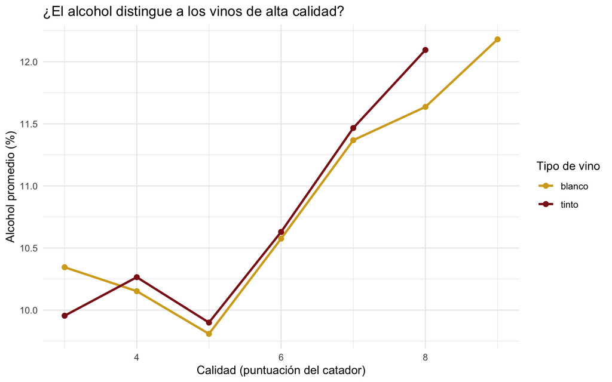

```r
# Visualizamos la relación
vinos |>
  group_by(tipo, quality) |>
  summarise(alcohol_medio = mean(alcohol), .groups = "drop") |>
  ggplot(aes(x = quality, y = alcohol_medio, color = tipo, group = tipo)) +
  geom_line(size = 1) +
  geom_point(size = 2) +
  scale_color_manual(values = c("tinto" = "#8B1A1A", "blanco" = "#D4A820")) +
  labs(
    title = "¿El alcohol distingue a los vinos de alta calidad?",
    x     = "Calidad (puntuación del catador)",
    y     = "Alcohol promedio (%)",
    color = "Tipo de vino"
  ) +
  theme_minimal()
```

## 12.2 Pregunta 2: ¿Cómo se distribuye el IMC por tabaquismo y nivel educativo en el dataset de salud?

```r
salud |>
  filter(!is.na(SmokingStatus), !is.na(EducationLevel), !is.na(BMI)) |>
  group_by(SmokingStatus, EducationLevel) |>
  summarise(
    media_imc = round(mean(BMI, na.rm = TRUE), 1),
    n         = n(),
    .groups   = "drop"
  ) |>
  arrange(SmokingStatus, desc(media_imc))
```

```
# A tibble: 10 × 4
   SmokingStatus EducationLevel media_imc     n
   <chr>         <chr>              <dbl> <int>
 1 Ex-fumadora   Preparatoria        97.4     1
 2 Ex-fumadora   Licenciatura        69.4     2
 3 Ex-fumadora   Secundaria          35.7     1
 4 Ex-fumadora   Posgrado            26.6     1
 5 Fuma          Posgrado            75.1     1
 6 Fuma          Secundaria          56.9     1
 7 Fuma          Licenciatura        52.6     2
 8 Fuma          Preparatoria        34.9     2
 9 No fuma       Secundaria          37.2     5
10 No fuma       Posgrado            12.4     1
```

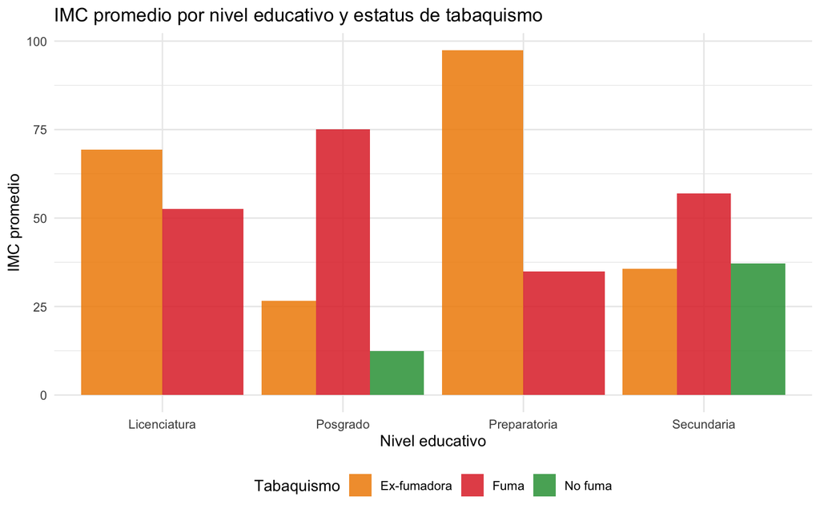

```r
# Visualizamos el perfil por educación y tabaquismo
salud |>
  filter(!is.na(SmokingStatus), !is.na(EducationLevel), !is.na(BMI)) |>
  group_by(SmokingStatus, EducationLevel) |>
  summarise(media_imc = round(mean(BMI, na.rm = TRUE), 1), .groups = "drop") |>
  ggplot(aes(x = EducationLevel, y = media_imc, fill = SmokingStatus)) +
  geom_col(position = "dodge", alpha = 0.85) +
  scale_fill_manual(
    values = c("Fuma" = "#E03131", "No fuma" = "#2F9E44", "Ex-fumadora" = "#F08C00")
  ) +
  labs(
    title = "IMC promedio por nivel educativo y estatus de tabaquismo",
    x     = "Nivel educativo",
    y     = "IMC promedio",
    fill  = "Tabaquismo"
  ) +
  theme_minimal() +
  theme(legend.position = "bottom")
```

# 13 Resumen de lo aprendido

| Verbo | ¿Qué hace? | Equivalente en R base |
| --- | --- | --- |
| `filter()` | Filtra filas por condición | `df[condición, ]` |
| `select()` | Elige columnas | `df[, c("col1","col2")]` |
| `arrange()` | Ordena filas | `df[order(df$col), ]` |
| `mutate()` | Crea/modifica columnas | `df$nueva <- ...` |
| `summarise()` | Resume a una fila | `mean()`, `sum()`, etc. |
| `group_by()` | Agrupa para operaciones por grupo | `tapply()`, `aggregate()` |
| `*_join()` | Une dos tablas por una llave | `merge()` |

**El pipe (`|>`)** permite encadenar todos estos verbos de forma legible, de arriba a abajo.

**Nota🏆 Ejercicio integrador final**

Usando los dos datasets (`vinos` y `salud`), responde las siguientes preguntas:

**A)** ¿Cuál es el promedio de calidad de los vinos **blancos** de categoría “Alta” o “Excepcional”, agrupado por nivel de alcohol (`nivel_alcohol`)?  
*Pista:* primero crea la columna `nivel_alcohol` con `mutate()` y `case_when()`.

**B)** En el dataset `salud`, ¿qué 5 participantes tienen la mayor diferencia entre su BMI y el BMI promedio de su grupo educativo? Muestra su ID, nivel educativo, BMI individual y la diferencia.

**Tip✅ Solución del ejercicio integrador**

```r
# A) Vinos blancos de calidad alta/excepcional agrupados por nivel de alcohol
vinos |>
  filter(tipo == "blanco", categoria %in% c("Alta", "Excepcional")) |>
  mutate(
    nivel_alcohol = case_when(
      alcohol < 10  ~ "Bajo",
      alcohol <= 12 ~ "Medio",
      TRUE          ~ "Alto"
    )
  ) |>
  group_by(nivel_alcohol) |>
  summarise(
    n             = n(),
    calidad_media = round(mean(quality), 2),
    .groups       = "drop"
  ) |>
  arrange(desc(calidad_media))
```

```
# A tibble: 3 × 3
  nivel_alcohol     n calidad_media
  <chr>         <int>         <dbl>
1 Alto            375          7.24
2 Bajo            145          7.15
3 Medio           540          7.13
```

```r
# B) Top 5 participantes con mayor desvío de BMI respecto a su grupo educativo
salud |>
  filter(!is.na(EducationLevel), !is.na(BMI)) |>
  group_by(EducationLevel) |>
  mutate(
    imc_prom_educ  = round(mean(BMI, na.rm = TRUE), 1),
    diferencia_imc = round(abs(BMI - imc_prom_educ), 2)
  ) |>
  ungroup() |>
  slice_max(diferencia_imc, n = 5) |>
  select(ID, EducationLevel, BMI, imc_prom_educ, diferencia_imc)
```

```
# A tibble: 5 × 5
  ID    EducationLevel   BMI imc_prom_educ diferencia_imc
  <chr> <chr>          <dbl>         <dbl>          <dbl>
1 id11  Preparatoria   97.4           42.5           54.9
2 id19  Secundaria     99.0           47.2           51.8
3 id8   Secundaria      6.63          47.2           40.6
4 id20  Preparatoria    2.73          42.5           39.8
5 id4   Posgrado       75.1           38             37.1
```